# Mass Incarceration

Matthew Schrier, Abdirahim M, Confedence, Aminata

2/19/2021

## Introduction:

*Mass incarceration is an astronomical problem in the United States. The U.S. leads with the highest incarceration rate of any country in the world. Not really something that should be celebrated. Research has shown that it is mainly African-Americans that inhabit these prisons/jails. Is there a societal problem? Can we expose this great injustice to the individuals that, one could say, built this country? Lets find out!*

# Summary:

[output not shown]

[output not shown]

# Table:

Arrest Info

| year | total arrest | black arrest | white arrest | american indian or alaska native arrest | asian arrests | native hawaiian or other pacific islander arrest |
| --- | --- | --- | --- | --- | --- | --- |
| 2013 | 9014635 | 2549655 | 6214197 | 140290 | 105109 | 5384 |
| 2015 | 8248709 | 2197140 | 5753212 | 174020 | 101064 | 23273 |
| 2017 | 8162849 | 2221697 | 5626140 | 196908 | 97049 | 21055 |
| 2019 | 6816975 | 1815144 | 4729290 | 164852 | 86733 | 20956 |

# Charts:

[figure not shown]

[figure not shown]

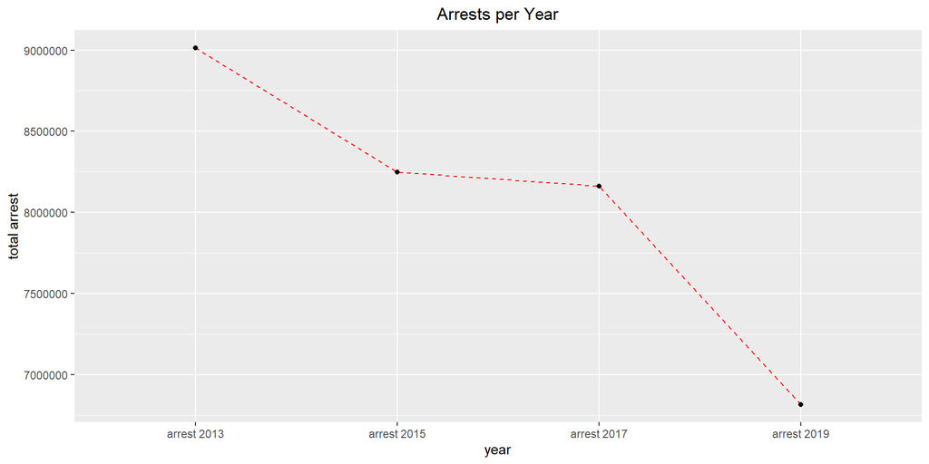

- Description: The purpose of the first chart is to show that arrests have been declining from 2013 to 2019. We can see that in 2013,2015,2017, and 2019 there was a decline in every year. I think that this is good news. There has been a lot more awareness around Mass incarceration and this has helped to reduce arrests arrests. ALso, some laws concerning drugs have been changed to help reduce the total number of arrests.

```
##  total_arrest           Total
##  Length:30          Min.   :   1316
##  Class :character   1st Qu.:  17402
##  Mode  :character   Median :  70867
##                     Mean   : 264910
##                     3rd Qu.: 260306
##                     Max.   :2192791
```

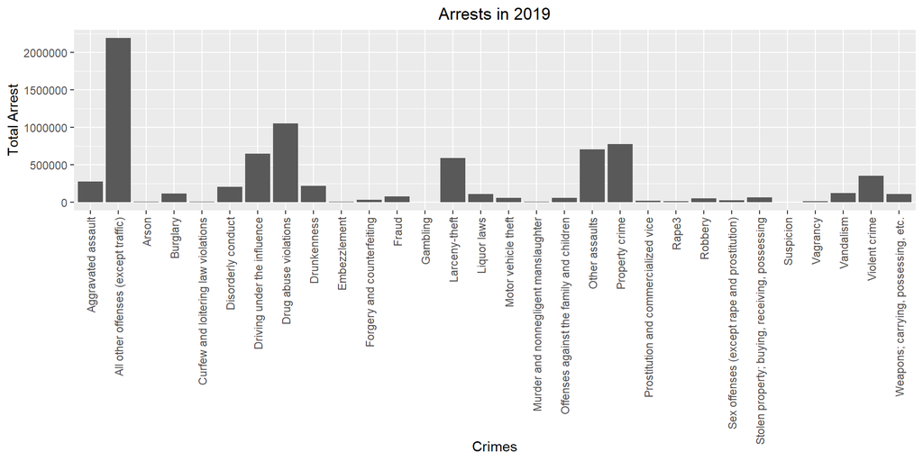

- Description: The purpose of the second chart is to show all the different crimes people are arrested for. This chart allows us to quickly see the crimes that are causing the most arrests. For instance, one observation that drug abuse violations, other assaults,property crime, along with a category titled all other offense, which we could not find more information on were the crimes that had the most arrests.

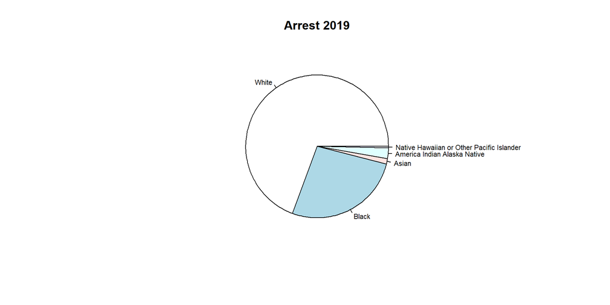

- Description: The purpose of the third chart is to show that though our pie chart of arrests show that White people were arrested more in 2019, Black people are still arrested at a higher rate than all races. The explanation being that the Black population is less than 14% in the U.S. whereas the White population is nearly 77%, according to the U.S. Census Bureau. Therefore, it makes sense that there will be a much greater number of White arrests but it makes absolutely no sense why the the number of Black arrests should come close or even be second to the number of White arrests considering the Hispanic or Latino population is higher than the Black population. This shows the issue of over-policing in the Black community. Our chart exposes that discrepancy and that is why we chose it.